# Injustice in Our Justice System

Ethan Side

2022-11-01

## Abstract

The US justice system has been something that for centuries has set the country apart yet over the last couple decades it has filled the prison and jail systems in an inequitable way. The following visualizations can shed some light n these injustices. In hopes that awareness can be spread to help promote equity for all.

## Introduction

The Vera Institute allows viewers of their data set to delve into decades worth of jail and prison populations from the United States of America and the states and counties within. The Vera Institute also allows us to see the total populations certain genders and races so that comparisons can be made in order for us to see possible injustices in the United States justice system. Direct stakeholders for a data set like this are policy makers, socially aware citizens. They can access a data set like this and cause change in society. A policy maker can see a march by a citizen and make change based off this kind of data. Indirectly those who are incarcerated might be able to be set free if certain laws were passed, and also indirectly would be every US citizen as their justice system could start to become more equitable if the direct stakeholders are able to harness the data in the right way. Some of the questions I will answer in this report are: What are certain states jail populations over a quarter decade? How has the US Prison population fluctuated over a quarter decade? What counties in Alabama disenfranchise African-Americans?

## Growth of U.S. Prison Population

[figure not shown]

```r
chart3
```

**United States prison population over a 26 year period from 1990 to 2016**

# Section 4: Growth of Prison Population by State

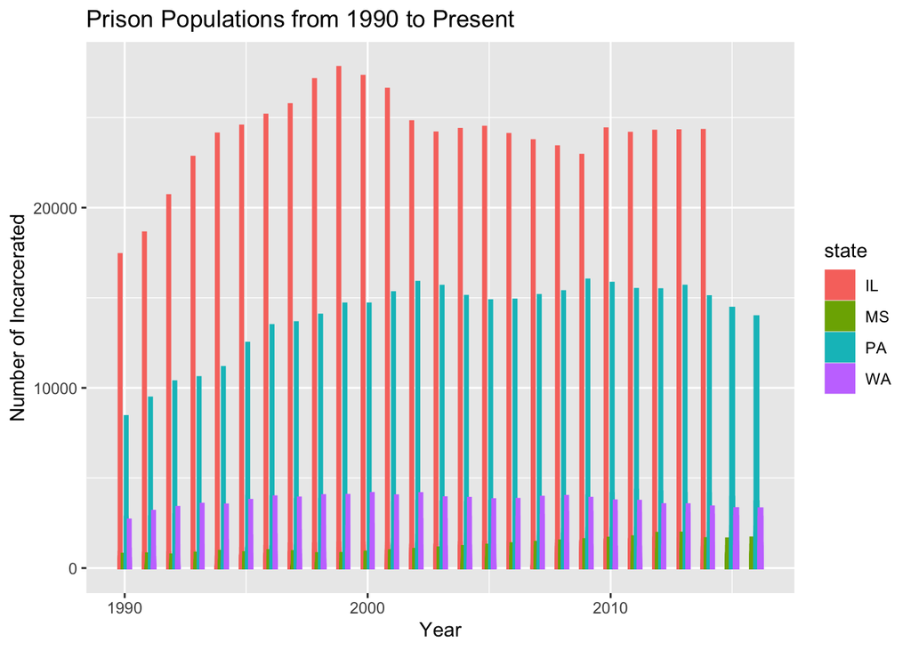

```r
chart4
```

**Prison Populations from 1990 to 2016 in Washington, Mississippi,** **Illinois, and Pennsylvania**

Why the stark difference in incarcerated totals? These four states all in different regions of the United States have differing state populations and answer the question of the large range between each state. Another sore thumb in this data set is the massive upswing in incarcerations in Illinois during the 90s. This could be because of the general growth of the state’s population but is more likely due to race riots happening during that era and more brutal police enforcement, especially in large urban areas like Chicago. This uptick is noticeable in Pennsylvania too.

# Section 5: Washington State Jail Distribution is Unequitable

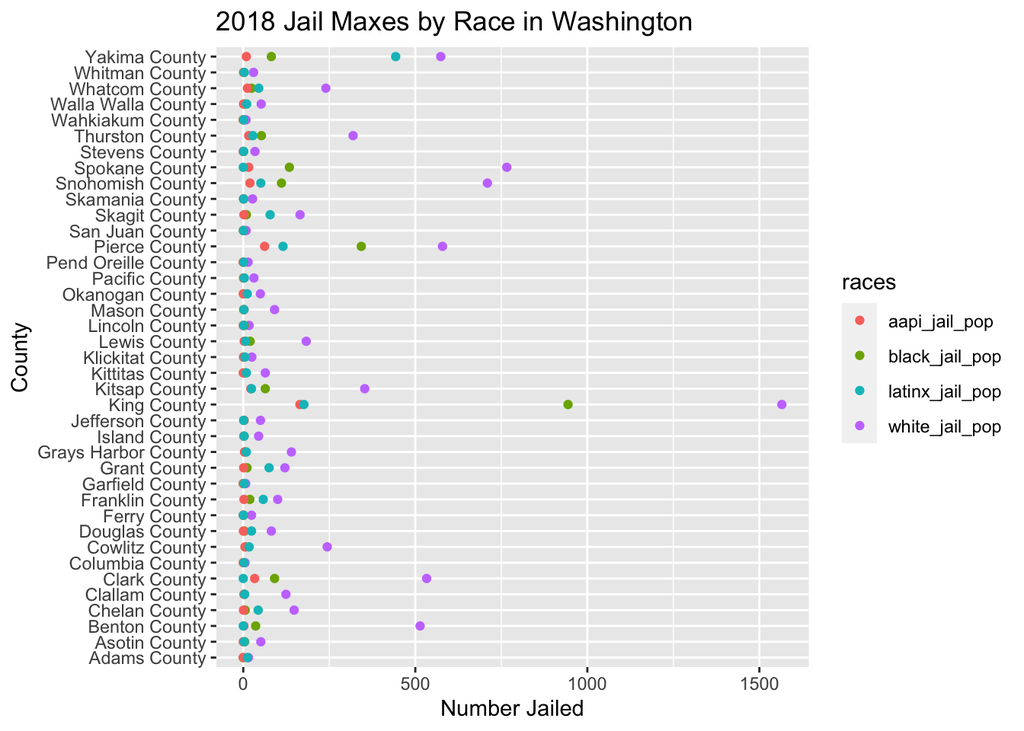

```r
plot5
```

**Washington counties max jail population by race in 2018**

When it comes to each counties max jail population in the latest year we have data for what is the order that the races come in? In other words is there a consistent pattern of races when it comes to the hierarchy of jail populations. As it turns out in the state of Washington most counties, in descending order, tend to go from white, black, latinx, to Asian-american pacific islanders. This ordering is intriguing as latinx populations in Washington are second only to the white population. In counties like Yakima and Skagit this swap between the black max and the latinx max exist resulting in what should be a better representation of the Washington population. The black community being the second highest prison populator is a major inequality in the state.

# Section 6: African-American Inequality in the Jail Population of Alabama Counties

[figure not shown]

```r
plot6
```

**Alabama racial inequalities toward African-Americans over the last 30 years by county**